# Getting Started

panelforest builds forest plots by composing panel specifications with `|>`. The workflow has three steps:

1. `forest_plot(data)` — initialise from a data frame
2. `add_*()` — append panels left-to-right
3. `fp_render()` — assemble and return a patchwork object for display or saving

## Minimal example

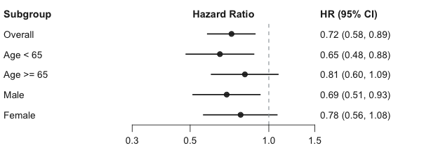

```r
df <- data.frame(
  label = c("Overall", "Age < 65", "Age >= 65", "Male", "Female"),
  HR    = c(0.72, 0.65, 0.81, 0.69, 0.78),
  LCI   = c(0.58, 0.48, 0.60, 0.51, 0.56),
  UCI   = c(0.89, 0.88, 1.09, 0.93, 1.08)
)

forest_plot(df) |>
  add_text("label", header = "Subgroup", width = 2) |>
  add_ci("HR", "LCI", "UCI",
         header = "Hazard Ratio", trans = "log",
         xlim = c(0.3, 1.5), breaks = c(0.3, 0.5, 1.0, 1.5),
         show_axis = TRUE, width = 3) |>
  add_text_ci("HR", "LCI", "UCI", header = "HR (95% CI)", width = 1.8) |>
  fp_render()
```

## Panel types

### Text panel — `add_text()`

Displays a character or numeric column. Use `align` for content and `header_align` for the column header independently.

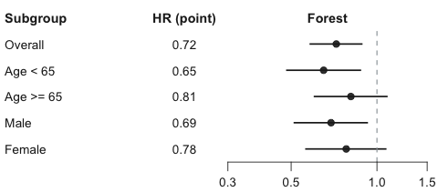

```r
forest_plot(df) |>
  add_text("label", header = "Subgroup",     align = "left",   width = 2.0) |>
  add_text("HR",    header = "HR (point)",   align = "center", width = 1.2) |>
  add_ci("HR", "LCI", "UCI",
         header = "Forest", trans = "log", width = 3,
         show_axis = TRUE, xlim = c(0.3, 1.5),
         breaks = c(0.3, 0.5, 1.0, 1.5)) |>
  fp_render()
```

### Text-CI panel — `add_text_ci()`

Formats `est (lower, upper)` as a single text column.

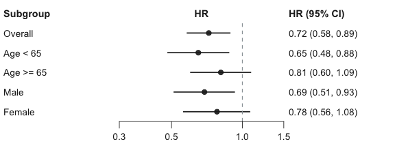

```r
forest_plot(df) |>
  add_text("label", header = "Subgroup", width = 2) |>
  add_ci("HR", "LCI", "UCI", header = "HR", trans = "log", width = 3,
         show_axis = TRUE, xlim = c(0.3, 1.5), breaks = c(0.3, 0.5, 1.0, 1.5)) |>
  add_text_ci("HR", "LCI", "UCI", header = "HR (95% CI)",
              digits = 2, width = 1.8) |>
  fp_render()
```

### Bar panel — `add_bar()`

Draws a horizontal bar proportional to a numeric column value.

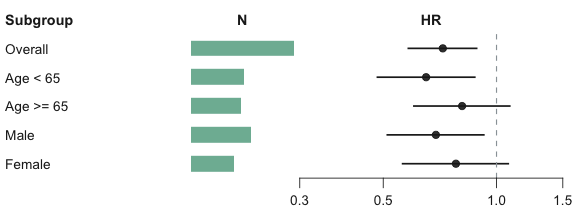

```r
df2 <- df
df2$n <- c(247, 128, 119, 143, 104)

forest_plot(df2) |>
  add_text("label", header = "Subgroup", width = 2) |>
  add_bar("n", header = "N", width = 1.2, fill = "#7eb8a2") |>
  add_ci("HR", "LCI", "UCI", header = "HR", trans = "log", width = 3,
         show_axis = TRUE, xlim = c(0.3, 1.5), breaks = c(0.3, 0.5, 1.0, 1.5)) |>
  fp_render()
```

### Dot panel — `add_dot()`

Plots a point estimate with optional error bars; useful for continuous outcomes such as mean differences.

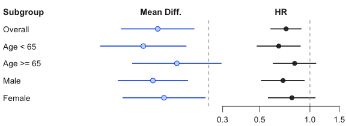

```r
df3 <- df2
df3$diff   <- c(-0.32, -0.41, -0.20, -0.35, -0.28)
df3$diff_l <- c(-0.55, -0.68, -0.48, -0.57, -0.54)
df3$diff_u <- c(-0.09, -0.14,  0.08, -0.13, -0.02)

forest_plot(df3) |>
  add_text("label", header = "Subgroup", width = 2) |>
  add_dot("diff", lower = "diff_l", upper = "diff_u",
          header = "Mean Diff.", ref_line = 0,
          colour = "#2563eb", fill = "#bfdbfe", shape = 21,
          breaks = c(-0.8, -0.4, 0, 0.4), width = 2.5) |>
  add_ci("HR", "LCI", "UCI", header = "HR", trans = "log", width = 2.5,
         show_axis = TRUE, xlim = c(0.3, 1.5), breaks = c(0.3, 0.5, 1.0, 1.5)) |>
  fp_render()
```

### Gap and spacer — `add_gap()` / `add_spacer()`

`add_gap()` inserts a proportional-width empty column; `add_spacer()` inserts a column with a fixed absolute width.

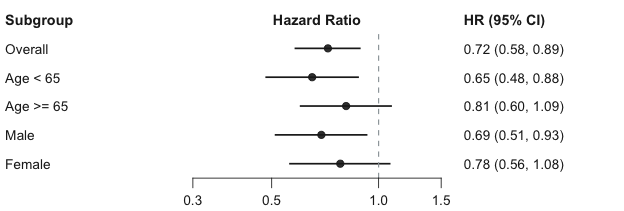

```r
forest_plot(df) |>
  add_text("label", header = "Subgroup", width = 2) |>
  add_gap(width = 0.15) |>
  add_ci("HR", "LCI", "UCI", header = "Hazard Ratio", trans = "log", width = 3,
         show_axis = TRUE, xlim = c(0.3, 1.5), breaks = c(0.3, 0.5, 1.0, 1.5)) |>
  add_spacer(width = 4, unit = "mm") |>
  add_text_ci("HR", "LCI", "UCI", header = "HR (95% CI)", width = 1.8) |>
  fp_render()
```

## Row structure

### Alternating stripes — `add_stripe()`

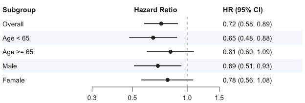

```r
forest_plot(df) |>
  add_stripe(c("#ffffff", "#f5f7fa")) |>
  add_text("label", header = "Subgroup", width = 2) |>
  add_ci("HR", "LCI", "UCI", header = "Hazard Ratio", trans = "log", width = 3,
         show_axis = TRUE, xlim = c(0.3, 1.5), breaks = c(0.3, 0.5, 1.0, 1.5)) |>
  add_text_ci("HR", "LCI", "UCI", header = "HR (95% CI)", width = 1.8) |>
  fp_render()
```

### Summary row — `add_summary()`

Marks one or more rows as summary rows: the CI glyph switches to a diamond and the text is bolded automatically.

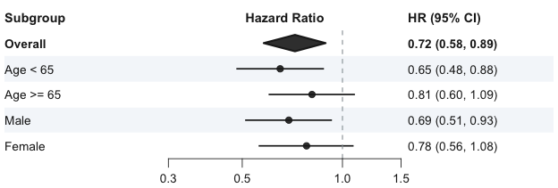

```r
forest_plot(df) |>
  add_stripe(c("#ffffff", "#f5f7fa")) |>
  add_summary(1) |>
  add_text("label", header = "Subgroup", width = 2) |>
  add_ci("HR", "LCI", "UCI", header = "Hazard Ratio", trans = "log", width = 3,
         show_axis = TRUE, xlim = c(0.3, 1.5), breaks = c(0.3, 0.5, 1.0, 1.5)) |>
  add_text_ci("HR", "LCI", "UCI", header = "HR (95% CI)", width = 1.8) |>
  fp_render()
```

### Group title row — `add_group()`

Designates rows as group headers: they are bolded, their CI glyphs are suppressed, and a background fill can be set.

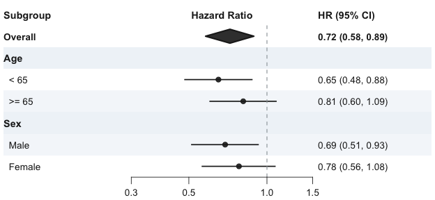

```r
df_grp <- data.frame(
  label = c("Overall", "Age", "  < 65", "  >= 65", "Sex", "  Male", "  Female"),
  HR    = c(0.72, NA,  0.65,  0.81, NA,  0.69, 0.78),
  LCI   = c(0.58, NA,  0.48,  0.60, NA,  0.51, 0.56),
  UCI   = c(0.89, NA,  0.88,  1.09, NA,  0.93, 1.08)
)

forest_plot(df_grp) |>
  add_stripe(c("#ffffff", "#f5f7fa")) |>
  add_summary(1) |>
  add_group(c(2, 5), fill = "#f0f4f8") |>
  add_text("label", header = "Subgroup", width = 2) |>
  add_ci("HR", "LCI", "UCI", header = "Hazard Ratio", trans = "log", width = 3,
         show_axis = TRUE, xlim = c(0.3, 1.5), breaks = c(0.3, 0.5, 1.0, 1.5)) |>
  add_text_ci("HR", "LCI", "UCI", header = "HR (95% CI)", width = 1.8) |>
  fp_render()
```

### Horizontal separator — `add_hline()`

Draws a thin rule below the specified rows.

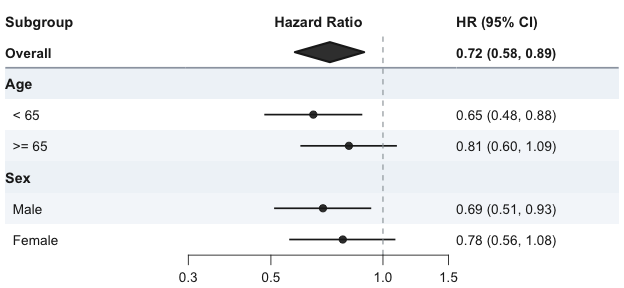

```r
forest_plot(df_grp) |>
  add_stripe(c("#ffffff", "#f5f7fa")) |>
  add_summary(1) |>
  add_group(c(2, 5), fill = "#f0f4f8") |>
  add_hline(1, colour = "#9ca3af", linewidth = 0.6) |>
  add_text("label", header = "Subgroup", width = 2) |>
  add_ci("HR", "LCI", "UCI", header = "Hazard Ratio", trans = "log", width = 3,
         show_axis = TRUE, xlim = c(0.3, 1.5), breaks = c(0.3, 0.5, 1.0, 1.5)) |>
  add_text_ci("HR", "LCI", "UCI", header = "HR (95% CI)", width = 1.8) |>
  fp_render()
```

## Editing rows and cells — `edit()`

`edit()` is the unified interface for styling. Omit `panel` for row-level overrides; supply `panel` for cell-level overrides.

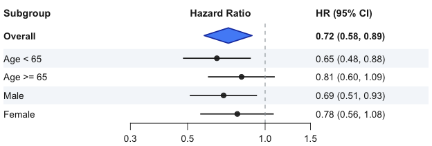

```r
forest_plot(df) |>
  add_stripe(c("#ffffff", "#f5f7fa")) |>
  add_text("label", header = "Subgroup", width = 2) |>
  add_ci("HR", "LCI", "UCI", header = "Hazard Ratio", trans = "log", width = 3,
         show_axis = TRUE, xlim = c(0.3, 1.5), breaks = c(0.3, 0.5, 1.0, 1.5)) |>
  add_text_ci("HR", "LCI", "UCI", header = "HR (95% CI)", width = 1.8) |>
  # row-level: bold + taller overall row
  edit(row = 1, fontface = "bold", height = 0.55) |>
  # cell-level: blue diamond for overall CI
  edit(row = 1, panel = "Hazard Ratio",
       glyph = "diamond", fill = "#3b82f6", colour = "#1e40af") |>
  fp_render()
```

The `panel` argument accepts the panel’s header string, its column name, or its integer index.

## Themes

Two built-in themes are provided. All parameters can be overridden.

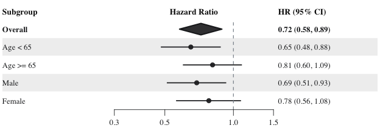

```r
# Journal theme: serif font, slightly smaller text
forest_plot(df, theme = fp_theme_journal()) |>
  add_stripe(c("#ffffff", "#f0f0f0")) |>
  add_summary(1) |>
  add_text("label", header = "Subgroup", width = 2) |>
  add_ci("HR", "LCI", "UCI", header = "Hazard Ratio", trans = "log", width = 3,
         show_axis = TRUE, xlim = c(0.3, 1.5), breaks = c(0.3, 0.5, 1.0, 1.5)) |>
  add_text_ci("HR", "LCI", "UCI", header = "HR (95% CI)", width = 1.8) |>
  fp_render()
```

Custom theme values:

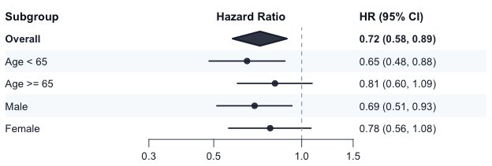

```r
my_theme <- fp_theme_default(
  text_colour    = "#1e293b",
  header_colour  = "#0f172a",
  refline_colour = "#94a3b8",
  text_size      = 3.5,
  plot_margin    = 5
)

forest_plot(df, theme = my_theme) |>
  add_stripe(c("#ffffff", "#f8fafc")) |>
  add_summary(1) |>
  add_text("label", header = "Subgroup", width = 2) |>
  add_ci("HR", "LCI", "UCI", header = "Hazard Ratio", trans = "log", width = 3,
         show_axis = TRUE, xlim = c(0.3, 1.5), breaks = c(0.3, 0.5, 1.0, 1.5)) |>
  add_text_ci("HR", "LCI", "UCI", header = "HR (95% CI)", width = 1.8) |>
  fp_render()
```

## Formatter helpers

`fp_fmt_*()` returns a formatter function suitable for the `formatter` argument of `add_text()`.

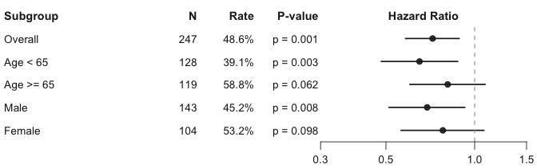

```r
df4 <- df2
df4$rate <- c(0.486, 0.391, 0.588, 0.452, 0.532)
df4$pval <- c(0.001, 0.003, 0.062, 0.008, 0.098)

forest_plot(df4) |>
  add_text("label",  header = "Subgroup",      width = 2.0) |>
  add_text("n",      header = "N",             width = 0.7,
           formatter = fp_fmt_number(digits = 0), align = "right") |>
  add_text("rate",   header = "Rate",          width = 0.8,
           formatter = fp_fmt_percent(digits = 1), align = "right") |>
  add_text("pval",   header = "P-value",       width = 0.9,
           formatter = fp_fmt_pvalue(digits = 3), align = "right") |>
  add_ci("HR", "LCI", "UCI", header = "Hazard Ratio", trans = "log", width = 3,
         show_axis = TRUE, xlim = c(0.3, 1.5), breaks = c(0.3, 0.5, 1.0, 1.5)) |>
  fp_render()
```

## Saving plots

`fp_size()` returns the exact `width` and `height` in inches for `ggsave()`.

```r
plot_obj <- forest_plot(df) |>
  add_text("label", header = "Subgroup", width = 2) |>
  add_ci("HR", "LCI", "UCI", header = "Hazard Ratio", trans = "log", width = 3,
         show_axis = TRUE)

size <- fp_size(plot_obj)

ggplot2::ggsave(
  "forest.png",
  plot   = fp_render(plot_obj),
  width  = size["width"],
  height = size["height"],
  dpi    = 300,
  bg     = "white"
)
```